# Hospital_Regression_model

```python
import os
import pandas as pd
import numpy as np
from sklearn import preprocessing
import pandas_profiling as pp
import matplotlib.pyplot as plt
import seaborn as sns
from sklearn.model_selection import train_test_split
from sklearn.linear_model import LinearRegression
from sklearn.feature_selection import RFE
from sklearn import metrics
import statsmodels.formula.api as sm
%matplotlib inline
```

```python
import warnings
warnings.filterwarnings('ignore')
```

```python
pwd = os.getcwd()
```

```python
data = pd.read_csv('Hospital - Data.csv')
```

```python
pd.set_option('display.max_columns', None)
```

```python
data[:3]
```

|  | SL. | AGE | GENDER | MARITAL STATUS | KEY COMPLAINTS -CODE | BODY WEIGHT | BODY HEIGHT | HR PULSE | BP -HIGH | BP-LOW | RR | PAST MEDICAL HISTORY CODE | HB | UREA | CREATININE | MODE OF ARRIVAL | STATE AT THE TIME OF ARRIVAL | TYPE OF ADMSN | TOTAL LENGTH OF STAY | LENGTH OF STAY - ICU | LENGTH OF STAY- WARD | IMPLANT USED (Y/N) | COST OF IMPLANT | TOTAL COST TO HOSPITAL |
| --- | --- | --- | --- | --- | --- | --- | --- | --- | --- | --- | --- | --- | --- | --- | --- | --- | --- | --- | --- | --- | --- | --- | --- | --- |
| 0 | 1 | 58.0 | M | MARRIED | other- heart | 49.2 | 160 | 118 | 100.0 | 80.0 | 32 | NaN | 11.4 | 33.0 | 0.8 | AMBULANCE | ALERT | EMERGENCY | 25 | 12 | 13 | Y | 38000 | 660293.0 |
| 1 | 2 | 59.0 | M | MARRIED | CAD-DVD | 41.0 | 155 | 78 | 70.0 | 50.0 | 28 | NaN | 11.4 | 95.0 | 1.7 | AMBULANCE | ALERT | EMERGENCY | 41 | 20 | 21 | Y | 39690 | 809130.0 |
| 2 | 3 | 82.0 | M | MARRIED | CAD-TVD | 46.6 | 164 | 100 | 110.0 | 80.0 | 20 | Diabetes2 | 11.8 | 15.0 | 0.8 | WALKED IN | ALERT | ELECTIVE | 18 | 9 | 9 | N | 0 | 362231.0 |

```python
data.shape
```

```
(248, 24)
```

```python
data.columns
```

```
Index(['SL.', 'AGE', 'GENDER', 'MARITAL STATUS', 'KEY COMPLAINTS -CODE',
       'BODY WEIGHT', 'BODY HEIGHT', 'HR PULSE', 'BP -HIGH', 'BP-LOW', 'RR',
       'PAST MEDICAL HISTORY CODE', 'HB', 'UREA', 'CREATININE',
       'MODE OF ARRIVAL', 'STATE AT THE TIME OF ARRIVAL', 'TYPE OF ADMSN',
       'TOTAL LENGTH OF STAY', 'LENGTH OF STAY - ICU', 'LENGTH OF STAY- WARD',
       'IMPLANT USED (Y/N)', 'COST OF IMPLANT', 'TOTAL COST TO HOSPITAL '],
      dtype='object')
```

```python
data.drop('SL.', 1, inplace=True)
```

```python
data.dtypes
```

```
AGE                             float64
GENDER                           object
MARITAL STATUS                   object
KEY COMPLAINTS -CODE             object
BODY WEIGHT                     float64
BODY HEIGHT                       int64
HR PULSE                          int64
BP -HIGH                        float64
BP-LOW                          float64
RR                                int64
PAST MEDICAL HISTORY CODE        object
HB                              float64
UREA                            float64
CREATININE                      float64
MODE OF ARRIVAL                  object
STATE AT THE TIME OF ARRIVAL     object
TYPE OF ADMSN                    object
TOTAL LENGTH OF STAY              int64
LENGTH OF STAY - ICU              int64
LENGTH OF STAY- WARD              int64
IMPLANT USED (Y/N)               object
COST OF IMPLANT                   int64
TOTAL COST TO HOSPITAL          float64
dtype: object
```

```python
# data.profile_report(style={'full_width':True})
```

```python
data.describe()
```

|  | AGE | BODY WEIGHT | BODY HEIGHT | HR PULSE | BP -HIGH | BP-LOW | RR | HB | UREA | CREATININE | TOTAL LENGTH OF STAY | LENGTH OF STAY - ICU | LENGTH OF STAY- WARD | COST OF IMPLANT | TOTAL COST TO HOSPITAL |
| --- | --- | --- | --- | --- | --- | --- | --- | --- | --- | --- | --- | --- | --- | --- | --- |
| count | 248.000000 | 248.000000 | 248.000000 | 248.000000 | 225.000000 | 225.000000 | 248.000000 | 246.000000 | 235.000000 | 215.000000 | 248.000000 | 248.000000 | 248.000000 | 248.000000 | 248.000000 |
| mean | 28.879837 | 37.524677 | 130.221774 | 92.229839 | 115.022222 | 71.875556 | 23.540323 | 12.894553 | 26.581702 | 0.746977 | 11.612903 | 3.475806 | 8.153226 | 8544.201613 | 198723.330282 |
| std | 25.899359 | 23.118822 | 39.170901 | 20.308740 | 22.536368 | 15.313176 | 3.840756 | 3.083237 | 15.998367 | 0.548641 | 5.392617 | 3.853520 | 3.755793 | 21521.877503 | 122587.492984 |
| min | 0.032877 | 2.020000 | 19.000000 | 41.000000 | 70.000000 | 39.000000 | 12.000000 | 5.000000 | 2.000000 | 0.100000 | 3.000000 | 0.000000 | 0.000000 | 0.000000 | 46093.000000 |
| 25% | 6.000000 | 15.000000 | 105.000000 | 78.000000 | 100.000000 | 60.000000 | 22.000000 | 11.300000 | 18.000000 | 0.300000 | 8.000000 | 1.000000 | 6.000000 | 0.000000 | 131652.750000 |
| 50% | 15.500000 | 40.900000 | 147.500000 | 90.000000 | 110.000000 | 70.000000 | 24.000000 | 12.350000 | 22.000000 | 0.700000 | 10.000000 | 2.000000 | 7.000000 | 0.000000 | 162660.500000 |
| 75% | 55.000000 | 58.250000 | 160.000000 | 104.000000 | 130.000000 | 80.000000 | 24.000000 | 14.000000 | 30.000000 | 1.000000 | 13.000000 | 4.000000 | 10.000000 | 0.000000 | 220614.000000 |
| max | 88.000000 | 85.000000 | 185.000000 | 155.000000 | 215.000000 | 140.000000 | 42.000000 | 25.700000 | 143.000000 | 5.200000 | 41.000000 | 30.000000 | 22.000000 | 196848.000000 | 887350.000000 |

```python
data.isnull().sum()
```

```
AGE                               0
GENDER                            0
MARITAL STATUS                    0
KEY COMPLAINTS -CODE             36
BODY WEIGHT                       0
BODY HEIGHT                       0
HR PULSE                          0
BP -HIGH                         23
BP-LOW                           23
RR                                0
PAST MEDICAL HISTORY CODE       173
HB                                2
UREA                             13
CREATININE                       33
MODE OF ARRIVAL                   0
STATE AT THE TIME OF ARRIVAL      0
TYPE OF ADMSN                     0
TOTAL LENGTH OF STAY              0
LENGTH OF STAY - ICU              0
LENGTH OF STAY- WARD              0
IMPLANT USED (Y/N)                0
COST OF IMPLANT                   0
TOTAL COST TO HOSPITAL            0
dtype: int64
```

```python
data.duplicated(subset=None, keep='first').value_counts()
```

```
False    240
True       8
dtype: int64
```

## Pre-processing

```python
data.loc[data['HB'].isna(), :]
```

|  | AGE | GENDER | MARITAL STATUS | KEY COMPLAINTS -CODE | BODY WEIGHT | BODY HEIGHT | HR PULSE | BP -HIGH | BP-LOW | RR | PAST MEDICAL HISTORY CODE | HB | UREA | CREATININE | MODE OF ARRIVAL | STATE AT THE TIME OF ARRIVAL | TYPE OF ADMSN | TOTAL LENGTH OF STAY | LENGTH OF STAY - ICU | LENGTH OF STAY- WARD | IMPLANT USED (Y/N) | COST OF IMPLANT | TOTAL COST TO HOSPITAL |
| --- | --- | --- | --- | --- | --- | --- | --- | --- | --- | --- | --- | --- | --- | --- | --- | --- | --- | --- | --- | --- | --- | --- | --- |
| 121 | 24.0 | F | MARRIED | RHD | 43.0 | 159 | 68 | 110.0 | 70.0 | 22 | NaN | NaN | NaN | NaN | WALKED IN | ALERT | ELECTIVE | 11 | 1 | 10 | Y | 20900 | 197865.00 |
| 142 | 6.0 | F | UNMARRIED | other- heart | 18.0 | 120 | 82 | 113.0 | 73.0 | 24 | NaN | NaN | NaN | NaN | WALKED IN | ALERT | ELECTIVE | 7 | 1 | 6 | N | 0 | 120367.81 |

Looking at the above 2 observations, it also has multiple missing fields besides Hemoglobin count. The dependent variable for these also have values close to average. Too many imputations for a single record is prone to incorrect values. Hence dropping them.

```python
data.dropna(subset=['HB'], inplace=True)
```

The other variables like Blood pressure, Urea and Creatinine also have missing values which approximately contribute to 10% of overall records. It's unwise to drop them. Hence imputing.

```python
imp_list = ['BP -HIGH', 'BP-LOW', 'UREA', 'CREATININE']

data[imp_list] = data[imp_list].fillna(data.mode().iloc[0])
```

The categorical variable with 2 types are label encoded

```python
le = preprocessing.LabelEncoder()

cat_col = ['GENDER', 'MARITAL STATUS', 'STATE AT THE TIME OF ARRIVAL', 'TYPE OF ADMSN', 'IMPLANT USED (Y/N)']

for i in cat_col:
    data[i] = le.fit_transform(data[i])
```

```python
le_class_mapping = {
  "GENDER" : {
    "M" : 1,
    "F" : 0
  },
  "MARITAL STATUS" : {
    "MARRIED" : 0,
    "UNMARRIED" : 1
  },
  "STATE AT THE TIME OF ARRIVAL" : {
    "ALERT" : 0,
    "CONFUSED" : 1
  },
    "TYPE OF ADMSN" : {
    "EMERGENCY" : 1,
    "ELECTIVE" : 0
  },
    "IMPLANT USED (Y/N)" : {
    "Y" : 1,
    "N" : 0
  }
}

le_class_mapping
```

```
{'GENDER': {'M': 1, 'F': 0},
 'MARITAL STATUS': {'MARRIED': 0, 'UNMARRIED': 1},
 'STATE AT THE TIME OF ARRIVAL': {'ALERT': 0, 'CONFUSED': 1},
 'TYPE OF ADMSN': {'EMERGENCY': 1, 'ELECTIVE': 0},
 'IMPLANT USED (Y/N)': {'Y': 1, 'N': 0}}
```

Other heart related admissions appear to be most frequent. Hence replacing the null values with 'other- heart'

```python
data['KEY COMPLAINTS -CODE'].fillna('other- heart', inplace = True)
```

Since almost 70% of Past Medical History Codes are unavailable, it's unsafe to consider this variable (without any imputation). So, let's drop the variable for now.

```python
data.drop('PAST MEDICAL HISTORY CODE', 1, inplace=True)
```

The Key Complaints Code and Mode of Arrival fields are One Hot Encoded using dummies to ensure they are numeric before modeling

```python
#Function for one hot encoding

def dummy_df(df, todummy_list):
    for x in todummy_list:
        dummies = pd.get_dummies(df[x], prefix=x, dummy_na=False)
        df = df.drop(x, 1)
        df = pd.concat([df, dummies], axis=1)
    return df
```

```python
#Extracting string columns

obj_cols = []
for i in data.columns:
    if data[i].dtypes == 'object':
        obj_cols.append(i)

obj_cols
```

```
['KEY COMPLAINTS -CODE', 'MODE OF ARRIVAL']
```

```python
data = dummy_df(data, obj_cols)
```

## Modeling

Cleary, the dependent variable is not normally distributed (Right skewed)

```python
data.columns
```

```
Index(['AGE', 'GENDER', 'MARITAL STATUS', 'BODY WEIGHT', 'BODY HEIGHT',
       'HR PULSE', 'BP -HIGH', 'BP-LOW', 'RR', 'HB', 'UREA', 'CREATININE',
       'STATE AT THE TIME OF ARRIVAL', 'TYPE OF ADMSN', 'TOTAL LENGTH OF STAY',
       'LENGTH OF STAY - ICU', 'LENGTH OF STAY- WARD', 'IMPLANT USED (Y/N)',
       'COST OF IMPLANT', 'TOTAL COST TO HOSPITAL ',
       'KEY COMPLAINTS -CODE_ACHD', 'KEY COMPLAINTS -CODE_CAD-DVD',
       'KEY COMPLAINTS -CODE_CAD-SVD', 'KEY COMPLAINTS -CODE_CAD-TVD',
       'KEY COMPLAINTS -CODE_CAD-VSD', 'KEY COMPLAINTS -CODE_OS-ASD',
       'KEY COMPLAINTS -CODE_PM-VSD', 'KEY COMPLAINTS -CODE_RHD',
       'KEY COMPLAINTS -CODE_other- heart',
       'KEY COMPLAINTS -CODE_other- respiratory',
       'KEY COMPLAINTS -CODE_other-general',
       'KEY COMPLAINTS -CODE_other-nervous',
       'KEY COMPLAINTS -CODE_other-tertalogy', 'MODE OF ARRIVAL_AMBULANCE',
       'MODE OF ARRIVAL_TRANSFERRED', 'MODE OF ARRIVAL_WALKED IN'],
      dtype='object')
```

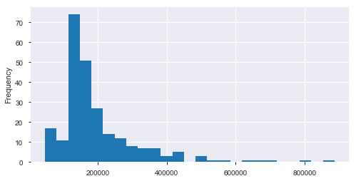

```python
data['TOTAL COST TO HOSPITAL '].plot.hist(bins=25,figsize=(8,4))
```

```python
X =  [x for x in data.columns if x!= 'TOTAL COST TO HOSPITAL ']
y = 'TOTAL COST TO HOSPITAL '
```

```python
X = data[X]
y = data[y]
```

```python
data.corr()
```

|  | AGE | GENDER | MARITAL STATUS | BODY WEIGHT | BODY HEIGHT | HR PULSE | BP -HIGH | BP-LOW | RR | HB | UREA | CREATININE | STATE AT THE TIME OF ARRIVAL | TYPE OF ADMSN | TOTAL LENGTH OF STAY | LENGTH OF STAY - ICU | LENGTH OF STAY- WARD | IMPLANT USED (Y/N) | COST OF IMPLANT | TOTAL COST TO HOSPITAL | KEY COMPLAINTS -CODE_ACHD | KEY COMPLAINTS -CODE_CAD-DVD | KEY COMPLAINTS -CODE_CAD-SVD | KEY COMPLAINTS -CODE_CAD-TVD | KEY COMPLAINTS -CODE_CAD-VSD | KEY COMPLAINTS -CODE_OS-ASD | KEY COMPLAINTS -CODE_PM-VSD | KEY COMPLAINTS -CODE_RHD | KEY COMPLAINTS -CODE_other- heart | … |
| --- | --- | --- | --- | --- | --- | --- | --- | --- | --- | --- | --- | --- | --- | --- | --- | --- | --- | --- | --- | --- | --- | --- | --- | --- | --- | --- | --- | --- | --- | --- |
| AGE | 1.000000 | 0.188313 | -0.901545 | 0.848279 | 0.719208 | -0.488723 | 0.598552 | 0.392513 | -0.284834 | -0.132305 | 0.219827 | 0.580592 | 0.101119 | 0.466056 | 0.212622 | 0.343522 | -0.053649 | 0.209346 | 0.181672 | 0.419440 | -0.130586 | 0.421726 | 0.118835 | 0.379665 | -0.064094 | -0.122543 | -0.150574 | 0.042155 | -0.122833 | … |
| GENDER | 0.188313 | 1.000000 | -0.171482 | 0.172746 | 0.144702 | -0.027986 | 0.172125 | 0.108491 | -0.014487 | 0.043612 | -0.027262 | 0.204440 | 0.044351 | 0.113671 | 0.107328 | 0.138836 | 0.012368 | -0.052339 | -0.024163 | 0.150503 | -0.124205 | 0.160471 | 0.062851 | 0.199010 | 0.044351 | -0.076952 | 0.053510 | -0.168578 | -0.049214 | … |
| MARITAL STATUS | -0.901545 | -0.171482 | 1.000000 | -0.832096 | -0.672332 | 0.475313 | -0.572508 | -0.368785 | 0.252107 | 0.098487 | -0.213941 | -0.535595 | -0.072817 | -0.391990 | -0.165878 | -0.282771 | 0.057867 | -0.271507 | -0.224286 | -0.374772 | 0.100260 | -0.347734 | -0.103190 | -0.374753 | 0.056053 | 0.155040 | 0.138725 | -0.084832 | 0.104633 | … |
| BODY WEIGHT | 0.848279 | 0.172746 | -0.832096 | 1.000000 | 0.850747 | -0.568312 | 0.596374 | 0.415338 | -0.316659 | -0.086965 | 0.158033 | 0.546167 | 0.061923 | 0.352075 | 0.051134 | 0.227806 | -0.162752 | 0.262487 | 0.276383 | 0.346915 | -0.157968 | 0.338975 | 0.085794 | 0.416002 | -0.069280 | -0.068620 | -0.187296 | 0.156439 | -0.133021 | … |
| BODY HEIGHT | 0.719208 | 0.144702 | -0.672332 | 0.850747 | 1.000000 | -0.534461 | 0.478219 | 0.321086 | -0.299657 | -0.055917 | 0.152931 | 0.487884 | 0.048653 | 0.275677 | 0.001637 | 0.139614 | -0.141831 | 0.306921 | 0.275555 | 0.293784 | -0.110226 | 0.254786 | 0.085112 | 0.294424 | -0.060537 | -0.031719 | -0.272839 | 0.240688 | -0.110476 | … |
| HR PULSE | -0.488723 | -0.027986 | 0.475313 | -0.568312 | -0.534461 | 1.000000 | -0.313249 | -0.160214 | 0.398544 | 0.028690 | -0.022444 | -0.384591 | -0.155527 | -0.152443 | 0.122014 | 0.037692 | 0.138795 | -0.126831 | -0.071771 | -0.009934 | 0.115605 | -0.137859 | -0.097632 | -0.251890 | 0.036637 | -0.038155 | 0.158242 | -0.058542 | -0.015519 | … |
| BP -HIGH | 0.598552 | 0.172125 | -0.572508 | 0.596374 | 0.478219 | -0.313249 | 1.000000 | 0.744397 | -0.135159 | -0.058120 | 0.048020 | 0.358450 | 0.075348 | 0.223376 | 0.034270 | 0.131915 | -0.092527 | 0.066677 | 0.041876 | 0.180115 | -0.083399 | 0.236109 | 0.001759 | 0.286075 | -0.072866 | -0.148753 | -0.155880 | 0.028382 | -0.069042 | … |
| BP-LOW | 0.392513 | 0.108491 | -0.368785 | 0.415338 | 0.321086 | -0.160214 | 0.744397 | 1.000000 | -0.052862 | 0.041167 | 0.017112 | 0.146840 | -0.054549 | 0.158037 | 0.026593 | 0.084220 | -0.050794 | 0.072325 | 0.062679 | 0.142151 | -0.122547 | 0.183420 | -0.046719 | 0.228320 | -0.097711 | -0.074112 | -0.081592 | 0.038215 | -0.080074 | … |
| RR | -0.284834 | -0.014487 | 0.252107 | -0.316659 | -0.299657 | 0.398544 | -0.135159 | -0.052862 | 1.000000 | 0.005896 | 0.041911 | -0.233321 | -0.175109 | -0.023341 | 0.176064 | 0.054422 | 0.201062 | 0.015607 | -0.020220 | 0.016496 | 0.105480 | -0.215349 | -0.036352 | -0.060798 | -0.025652 | -0.066990 | 0.005012 | 0.032809 | 0.063563 | … |
| HB | -0.132305 | 0.043612 | 0.098487 | -0.086965 | -0.055917 | 0.028690 | -0.058120 | 0.041167 | 0.005896 | 1.000000 | -0.064567 | -0.123357 | -0.024803 | -0.058264 | 0.012601 | -0.090243 | 0.115520 | -0.088504 | -0.089840 | -0.061601 | -0.098461 | -0.036994 | 0.006045 | -0.007165 | -0.037261 | -0.046478 | -0.053676 | -0.117457 | 0.026030 | … |
| UREA | 0.219827 | -0.027262 | -0.213941 | 0.158033 | 0.152931 | -0.022444 | 0.048020 | 0.017112 | 0.041911 | -0.064567 | 1.000000 | 0.448519 | -0.044777 | 0.398033 | 0.210794 | 0.233348 | 0.065913 | 0.176704 | 0.200549 | 0.258001 | 0.009441 | 0.067781 | 0.082795 | 0.095871 | 0.007836 | -0.084972 | -0.017333 | 0.103467 | -0.133145 | … |
| CREATININE | 0.580592 | 0.204440 | -0.535595 | 0.546167 | 0.487884 | -0.384591 | 0.358450 | 0.146840 | -0.233321 | -0.123357 | 0.448519 | 1.000000 | 0.540732 | 0.485363 | 0.179821 | 0.282328 | -0.032363 | 0.178067 | 0.182071 | 0.367241 | -0.123533 | 0.252691 | 0.069561 | 0.226910 | -0.046844 | -0.100752 | -0.106041 | 0.016003 | -0.008847 | … |
| STATE AT THE TIME OF ARRIVAL | 0.101119 | 0.044351 | -0.072817 | 0.061923 | 0.048653 | -0.155527 | 0.075348 | -0.054549 | -0.175109 | -0.024803 | -0.044777 | 0.540732 | 1.000000 | 0.165215 | -0.007509 | 0.024927 | -0.036617 | 0.129756 | 0.140772 | 0.078222 | -0.018483 | -0.022432 | -0.005784 | -0.021006 | -0.004082 | -0.016280 | -0.010102 | -0.021488 | 0.084112 | … |
| TYPE OF ADMSN | 0.466056 | 0.113671 | -0.391990 | 0.352075 | 0.275677 | -0.152443 | 0.223376 | 0.158037 | -0.023341 | -0.058264 | 0.398033 | 0.485363 | 0.165215 | 1.000000 | 0.294989 | 0.389125 | 0.025900 | 0.084042 | 0.078914 | 0.352913 | -0.066610 | 0.328129 | -0.035010 | 0.157937 | -0.024705 | -0.098539 | -0.061142 | -0.050073 | -0.067922 | … |
| TOTAL LENGTH OF STAY | 0.212622 | 0.107328 | -0.165878 | 0.051134 | 0.001637 | 0.122014 | 0.034270 | 0.026593 | 0.176064 | 0.012601 | 0.210794 | 0.179821 | -0.007509 | 0.294989 | 1.000000 | 0.721924 | 0.698279 | 0.136051 | 0.106759 | 0.698120 | -0.124315 | 0.276893 | 0.090040 | 0.073079 | 0.004332 | -0.064586 | -0.086963 | 0.010339 | -0.075197 | … |
| LENGTH OF STAY - ICU | 0.343522 | 0.138836 | -0.282771 | 0.227806 | 0.139614 | 0.037692 | 0.131915 | 0.084220 | 0.054422 | -0.090243 | 0.233348 | 0.282328 | 0.024927 | 0.389125 | 0.721924 | 1.000000 | 0.010142 | 0.152195 | 0.159629 | 0.822369 | -0.132022 | 0.319173 | -0.023391 | 0.210030 | -0.041366 | -0.112110 | -0.061359 | -0.053741 | -0.062690 | … |
| LENGTH OF STAY- WARD | -0.053649 | 0.012368 | 0.057867 | -0.162752 | -0.141831 | 0.138795 | -0.092527 | -0.050794 | 0.201062 | 0.115520 | 0.065913 | -0.032363 | -0.036617 | 0.025900 | 0.698279 | 0.010142 | 1.000000 | 0.039800 | -0.009596 | 0.159522 | -0.044294 | 0.061681 | 0.152830 | -0.108268 | 0.048361 | 0.030202 | -0.062580 | 0.072073 | -0.044683 | … |
| IMPLANT USED (Y/N) | 0.209346 | -0.052339 | -0.271507 | 0.262487 | 0.306921 | -0.126831 | 0.066677 | 0.072325 | 0.015607 | -0.088504 | 0.176704 | 0.178067 | 0.129756 | 0.084042 | 0.136051 | 0.152195 | 0.039800 | 1.000000 | 0.804013 | 0.426144 | -0.065600 | -0.008804 | 0.069651 | -0.058179 | -0.031456 | -0.125466 | -0.077850 | 0.649154 | -0.097131 | … |
| COST OF IMPLANT | 0.181672 | -0.024163 | -0.224286 | 0.276383 | 0.275555 | -0.071771 | 0.041876 | 0.062679 | -0.020220 | -0.089840 | 0.200549 | 0.182071 | 0.140772 | 0.078914 | 0.106759 | 0.159629 | -0.009596 | 0.804013 | 1.000000 | 0.483695 | -0.070893 | 0.009806 | 0.047555 | -0.065299 | -0.025291 | -0.100877 | -0.062592 | 0.591232 | -0.109482 | … |
| TOTAL COST TO HOSPITAL | 0.419440 | 0.150503 | -0.374772 | 0.346915 | 0.293784 | -0.009934 | 0.180115 | 0.142151 | 0.016496 | -0.061601 | 0.258001 | 0.367241 | 0.078222 | 0.352913 | 0.698120 | 0.822369 | 0.159522 | 0.426144 | 0.483695 | 1.000000 | -0.166273 | 0.318026 | 0.051765 | 0.212887 | -0.030452 | -0.120222 | -0.070066 | 0.160771 | -0.165465 | … |
| KEY COMPLAINTS -CODE_ACHD | -0.130586 | -0.124205 | 0.100260 | -0.157968 | -0.110226 | 0.115605 | -0.083399 | -0.122547 | 0.105480 | -0.098461 | 0.009441 | -0.123533 | -0.018483 | -0.066610 | -0.124315 | -0.132022 | -0.044294 | -0.065600 | -0.070893 | -0.166273 | 1.000000 | -0.101584 | -0.026193 | -0.095125 | -0.018483 | -0.073723 | -0.045744 | -0.097306 | -0.219747 | … |
| KEY COMPLAINTS -CODE_CAD-DVD | 0.421726 | 0.160471 | -0.347734 | 0.338975 | 0.254786 | -0.137859 | 0.236109 | 0.183420 | -0.215349 | -0.036994 | 0.067781 | 0.252691 | -0.022432 | 0.328129 | 0.276893 | 0.319173 | 0.061681 | -0.008804 | 0.009806 | 0.318026 | -0.101584 | 1.000000 | -0.031789 | -0.115449 | -0.022432 | -0.089475 | -0.055517 | -0.118096 | -0.266697 | … |
| KEY COMPLAINTS -CODE_CAD-SVD | 0.118835 | 0.062851 | -0.103190 | 0.085794 | 0.085112 | -0.097632 | 0.001759 | -0.046719 | -0.036352 | 0.006045 | 0.082795 | 0.069561 | -0.005784 | -0.035010 | 0.090040 | -0.023391 | 0.152830 | 0.069651 | 0.047555 | 0.051765 | -0.026193 | -0.031789 | 1.000000 | -0.029768 | -0.005784 | -0.023071 | -0.014315 | -0.030450 | -0.068767 | … |
| KEY COMPLAINTS -CODE_CAD-TVD | 0.379665 | 0.199010 | -0.374753 | 0.416002 | 0.294424 | -0.251890 | 0.286075 | 0.228320 | -0.060798 | -0.007165 | 0.095871 | 0.226910 | -0.021006 | 0.157937 | 0.073079 | 0.210030 | -0.108268 | -0.058179 | -0.065299 | 0.212887 | -0.095125 | -0.115449 | -0.029768 | 1.000000 | -0.021006 | -0.083785 | -0.051988 | -0.110587 | -0.249740 | … |
| KEY COMPLAINTS -CODE_CAD-VSD | -0.064094 | 0.044351 | 0.056053 | -0.069280 | -0.060537 | 0.036637 | -0.072866 | -0.097711 | -0.025652 | -0.037261 | 0.007836 | -0.046844 | -0.004082 | -0.024705 | 0.004332 | -0.041366 | 0.048361 | -0.031456 | -0.025291 | -0.030452 | -0.018483 | -0.022432 | -0.005784 | -0.021006 | 1.000000 | -0.016280 | -0.010102 | -0.021488 | -0.048526 | … |
| KEY COMPLAINTS -CODE_OS-ASD | -0.122543 | -0.076952 | 0.155040 | -0.068620 | -0.031719 | -0.038155 | -0.148753 | -0.074112 | -0.066990 | -0.046478 | -0.084972 | -0.100752 | -0.016280 | -0.098539 | -0.064586 | -0.112110 | 0.030202 | -0.125466 | -0.100877 | -0.120222 | -0.073723 | -0.089475 | -0.023071 | -0.083785 | -0.016280 | 1.000000 | -0.040291 | -0.085706 | -0.193552 | … |
| KEY COMPLAINTS -CODE_PM-VSD | -0.150574 | 0.053510 | 0.138725 | -0.187296 | -0.272839 | 0.158242 | -0.155880 | -0.081592 | 0.005012 | -0.053676 | -0.017333 | -0.106041 | -0.010102 | -0.061142 | -0.086963 | -0.061359 | -0.062580 | -0.077850 | -0.062592 | -0.070066 | -0.045744 | -0.055517 | -0.014315 | -0.051988 | -0.010102 | -0.040291 | 1.000000 | -0.053179 | -0.120096 | … |
| KEY COMPLAINTS -CODE_RHD | 0.042155 | -0.168578 | -0.084832 | 0.156439 | 0.240688 | -0.058542 | 0.028382 | 0.038215 | 0.032809 | -0.117457 | 0.103467 | 0.016003 | -0.021488 | -0.050073 | 0.010339 | -0.053741 | 0.072073 | 0.649154 | 0.591232 | 0.160771 | -0.097306 | -0.118096 | -0.030450 | -0.110587 | -0.021488 | -0.085706 | -0.053179 | 1.000000 | -0.255466 | … |
| KEY COMPLAINTS -CODE_other- heart | -0.122833 | -0.049214 | 0.104633 | -0.133021 | -0.110476 | -0.015519 | -0.069042 | -0.080074 | 0.063563 | 0.026030 | -0.133145 | -0.008847 | 0.084112 | -0.067922 | -0.075197 | -0.062690 | -0.044683 | -0.097131 | -0.109482 | -0.165465 | -0.219747 | -0.266697 | -0.068767 | -0.249740 | -0.048526 | -0.193552 | -0.120096 | -0.255466 | 1.000000 | … |
| KEY COMPLAINTS -CODE_other- respiratory | -0.194265 | -0.004423 | 0.189308 | -0.225270 | -0.201159 | 0.224874 | -0.058108 | -0.069521 | 0.136135 | -0.032123 | -0.039772 | -0.145392 | -0.016280 | -0.098539 | -0.042545 | -0.046005 | -0.014991 | -0.125466 | -0.100877 | -0.095060 | -0.073723 | -0.089475 | -0.023071 | -0.083785 | -0.016280 | -0.064935 | -0.040291 | -0.085706 | -0.193552 | … |
| KEY COMPLAINTS -CODE_other-general | 0.110982 | 0.044351 | -0.072817 | 0.073800 | 0.040504 | 0.030337 | 0.045705 | -0.011387 | 0.007561 | -0.066329 | 0.343750 | 0.145017 | -0.004082 | 0.165215 | -0.043033 | -0.024793 | -0.036617 | -0.031456 | -0.025291 | -0.074520 | -0.018483 | -0.022432 | -0.005784 | -0.021006 | -0.004082 | -0.016280 | -0.010102 | -0.021488 | -0.048526 | … |
| KEY COMPLAINTS -CODE_other-nervous | -0.118618 | -0.001928 | 0.097486 | -0.143227 | -0.166695 | 0.038151 | -0.075172 | -0.044826 | 0.013149 | -0.081654 | 0.041783 | -0.081470 | -0.007099 | -0.042966 | 0.014399 | 0.014529 | 0.005287 | -0.054707 | -0.043985 | -0.037032 | -0.032146 | -0.039014 | -0.010060 | -0.036533 | -0.007099 | -0.028314 | -0.017568 | -0.037371 | -0.084395 | … |
| KEY COMPLAINTS -CODE_other-tertalogy | -0.248799 | -0.004876 | 0.246521 | -0.243749 | -0.181826 | 0.166518 | -0.108976 | -0.008951 | 0.008907 | 0.403302 | -0.081233 | -0.162072 | -0.017951 | -0.108652 | -0.038811 | -0.109038 | 0.059047 | -0.138343 | -0.111229 | -0.071617 | -0.081289 | -0.098657 | -0.025438 | -0.092384 | -0.017951 | -0.071599 | -0.044426 | -0.094502 | -0.213416 | … |
| MODE OF ARRIVAL_AMBULANCE | 0.448414 | 0.099606 | -0.374649 | 0.353536 | 0.265744 | -0.121344 | 0.229149 | 0.158498 | 0.018271 | -0.056710 | 0.402984 | 0.482197 | 0.171429 | 0.963753 | 0.276238 | 0.380660 | 0.007818 | 0.098628 | 0.090959 | 0.353253 | -0.061287 | 0.306300 | -0.033741 | 0.128663 | -0.023810 | -0.094967 | -0.058926 | -0.043119 | -0.050952 | … |
| MODE OF ARRIVAL_TRANSFERRED | 0.029810 | -0.047972 | -0.016867 | 0.023447 | 0.016738 | -0.005515 | 0.047237 | -0.044629 | 0.031924 | -0.083338 | 0.023913 | 0.128943 | -0.008214 | -0.049715 | -0.032982 | -0.058230 | 0.011818 | -0.063301 | -0.050895 | -0.075797 | 0.083200 | -0.045142 | -0.011640 | -0.042272 | -0.008214 | -0.032761 | -0.020328 | -0.043241 | 0.035806 | … |
| MODE OF ARRIVAL_WALKED IN | -0.436090 | -0.076862 | 0.361407 | -0.343799 | -0.258101 | 0.117074 | -0.234580 | -0.133926 | -0.029023 | 0.084311 | -0.390855 | -0.504451 | -0.159531 | -0.895570 | -0.249830 | -0.339586 | -0.011744 | -0.070317 | -0.067592 | -0.307163 | 0.027620 | -0.273877 | 0.036257 | -0.106501 | 0.025585 | 0.102050 | 0.063320 | 0.056730 | 0.035189 | … |

```python
X_train, X_test, y_train, y_test = train_test_split(X, y, test_size=0.3, random_state=100)
```

```python
lm = LinearRegression()
lm.fit(X_train, y_train)
```

```
LinearRegression(copy_X=True, fit_intercept=True, n_jobs=None,
         normalize=False)
```

```python
train_pred = lm.predict(X_train)
```

```python
print('Train MAE:', metrics.mean_absolute_error(y_train, train_pred))
```

```
Train MAE: 28481.009491171568
```

```python
test_pred = lm.predict(X_test)
```

```python
print('Test MAE:', metrics.mean_absolute_error(y_test, test_pred))
```

```
Test MAE: 33673.440771910835
```

```python
print('Train RSquared value:', round(metrics.r2_score(y_train, train_pred), 2))
```

```
Train RSquared value: 0.87
```

```python
print('Test RSquared value:', round(metrics.r2_score(y_test, test_pred), 2))
```

```
Test RSquared value: 0.82
```

```python
reg_ols = sm.OLS(y, X).fit()
reg_ols.summary()
```

OLS Regression Results

| Dep. Variable: | TOTAL COST TO HOSPITAL | R-squared: | 0.870 |
| --- | --- | --- | --- |
| Model: | OLS | Adj. R-squared: | 0.850 |
| Method: | Least Squares | F-statistic: | 43.00 |
| Date: | Sat, 14 Sep 2019 | Prob (F-statistic): | 2.08e-76 |
| Time: | 18:43:56 | Log-Likelihood: | -2980.7 |
| No. Observations: | 246 | AIC: | 6029. |
| Df Residuals: | 212 | BIC: | 6149. |
| Df Model: | 33 |  |  |
| Covariance Type: | nonrobust |  |  |

|  | coef | std err | t | P>\|t\| | [0.025 | 0.975] |
| --- | --- | --- | --- | --- | --- | --- |
| AGE | 292.4337 | 345.147 | 0.847 | 0.398 | -387.925 | 972.793 |
| GENDER | -3640.0523 | 7264.890 | -0.501 | 0.617 | -1.8e+04 | 1.07e+04 |
| MARITAL STATUS | 5894.7073 | 1.59e+04 | 0.370 | 0.711 | -2.55e+04 | 3.73e+04 |
| BODY WEIGHT | -505.8784 | 410.864 | -1.231 | 0.220 | -1315.781 | 304.025 |
| BODY HEIGHT | 381.1132 | 166.688 | 2.286 | 0.023 | 52.536 | 709.691 |
| HR PULSE | 405.7111 | 206.717 | 1.963 | 0.051 | -1.772 | 813.194 |
| BP -HIGH | 108.4600 | 263.472 | 0.412 | 0.681 | -410.900 | 627.820 |
| BP-LOW | 1.9087 | 329.165 | 0.006 | 0.995 | -646.947 | 650.764 |
| RR | -330.2620 | 953.620 | -0.346 | 0.729 | -2210.053 | 1549.529 |
| HB | 204.1008 | 1137.050 | 0.180 | 0.858 | -2037.271 | 2445.473 |
| UREA | -489.1524 | 289.179 | -1.692 | 0.092 | -1059.187 | 80.882 |
| CREATININE | 3.69e+04 | 1.22e+04 | 3.021 | 0.003 | 1.28e+04 | 6.1e+04 |
| STATE AT THE TIME OF ARRIVAL | -1.332e+05 | 7.44e+04 | -1.790 | 0.075 | -2.8e+05 | 1.35e+04 |
| TYPE OF ADMSN | -5.296e+04 | 3.61e+04 | -1.465 | 0.144 | -1.24e+05 | 1.83e+04 |
| TOTAL LENGTH OF STAY | 13.4409 | 1.61e+04 | 0.001 | 0.999 | -3.18e+04 | 3.18e+04 |
| LENGTH OF STAY - ICU | 2.201e+04 | 1.61e+04 | 1.365 | 0.174 | -9774.527 | 5.38e+04 |
| LENGTH OF STAY- WARD | 5367.4303 | 1.6e+04 | 0.335 | 0.738 | -2.62e+04 | 3.69e+04 |
| IMPLANT USED (Y/N) | 1.761e+04 | 1.48e+04 | 1.191 | 0.235 | -1.15e+04 | 4.68e+04 |
| COST OF IMPLANT | 2.0398 | 0.257 | 7.943 | 0.000 | 1.534 | 2.546 |
| KEY COMPLAINTS -CODE_ACHD | -1.539e+04 | 1.52e+04 | -1.016 | 0.311 | -4.53e+04 | 1.45e+04 |
| KEY COMPLAINTS -CODE_CAD-DVD | 8472.9669 | 1.63e+04 | 0.519 | 0.605 | -2.37e+04 | 4.07e+04 |
| KEY COMPLAINTS -CODE_CAD-SVD | 1.276e+04 | 3.53e+04 | 0.362 | 0.718 | -5.67e+04 | 8.23e+04 |
| KEY COMPLAINTS -CODE_CAD-TVD | 2.67e+04 | 1.71e+04 | 1.559 | 0.120 | -7050.221 | 6.05e+04 |
| KEY COMPLAINTS -CODE_CAD-VSD | 1.428e+04 | 4.58e+04 | 0.312 | 0.756 | -7.6e+04 | 1.05e+05 |
| KEY COMPLAINTS -CODE_OS-ASD | -3082.5732 | 1.59e+04 | -0.193 | 0.847 | -3.45e+04 | 2.83e+04 |
| KEY COMPLAINTS -CODE_PM-VSD | 2.261e+04 | 2.12e+04 | 1.068 | 0.287 | -1.91e+04 | 6.44e+04 |
| KEY COMPLAINTS -CODE_RHD | -3.426e+04 | 1.84e+04 | -1.861 | 0.064 | -7.06e+04 | 2037.484 |
| KEY COMPLAINTS -CODE_other- heart | -1.701e+04 | 1.21e+04 | -1.412 | 0.160 | -4.08e+04 | 6744.344 |
| KEY COMPLAINTS -CODE_other- respiratory | -5998.2139 | 1.67e+04 | -0.358 | 0.720 | -3.9e+04 | 2.7e+04 |
| KEY COMPLAINTS -CODE_other-general | -9.287e+04 | 5.15e+04 | -1.802 | 0.073 | -1.94e+05 | 8727.793 |
| KEY COMPLAINTS -CODE_other-nervous | -1.122e+04 | 2.76e+04 | -0.407 | 0.685 | -6.56e+04 | 4.32e+04 |
| KEY COMPLAINTS -CODE_other-tertalogy | 1.755e+04 | 1.74e+04 | 1.011 | 0.313 | -1.67e+04 | 5.18e+04 |
| MODE OF ARRIVAL_AMBULANCE | 1.536e+04 | 5.5e+04 | 0.279 | 0.780 | -9.3e+04 | 1.24e+05 |
| MODE OF ARRIVAL_TRANSFERRED | -6.119e+04 | 4.43e+04 | -1.382 | 0.169 | -1.48e+05 | 2.61e+04 |
| MODE OF ARRIVAL_WALKED IN | -3.162e+04 | 3.59e+04 | -0.882 | 0.379 | -1.02e+05 | 3.91e+04 |

| Omnibus: | 224.993 | Durbin-Watson: | 1.908 |
| --- | --- | --- | --- |
| Prob(Omnibus): | 0.000 | Jarque-Bera (JB): | 9408.511 |
| Skew: | 3.306 | Prob(JB): | 0.00 |
| Kurtosis: | 32.567 | Cond. No. | 1.09e+16 |

Warnings:  
[1] Standard Errors assume that the covariance matrix of the errors is correctly specified.  
[2] The smallest eigenvalue is 1.12e-21. This might indicate that there are  
strong multicollinearity problems or that the design matrix is singular.

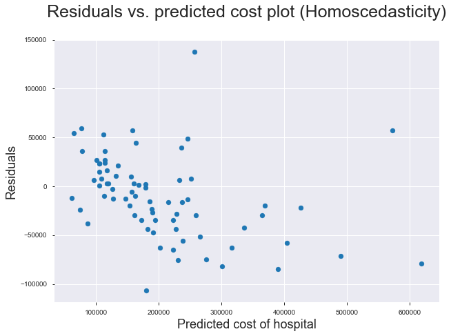

```python
plt.figure(figsize=(10,7))
plt.title("Residuals vs. predicted cost plot (Homoscedasticity)\n",fontsize=25)
plt.xlabel("Predicted cost of hospital",fontsize=18)
plt.ylabel("Residuals", fontsize=18)
plt.scatter(x=test_pred,y=y_test-test_pred)
```

```python
#Feature selection to check if accuracy can be improved
```

```python
data.shape
```

```
(246, 36)
```

```python
rfe = RFE(lm, 10)
rfe = rfe.fit(X, y)
print(rfe.support_)
print(rfe.ranking_)
```

```
[False False False False False False False False False False False  True
  True False False False False  True False False  True  True  True  True
 False False False False False  True False  True  True False False]
[18 11 10 15 20 17 23 26 16 24 21  1  1  2 19  3  9  1 25  6  1  1  1  1
 12  8 14  7 13  1  5  1  1  4 22]
```

```python
rfe_index = [11, 12, 17, 20, 21, 22, 23, 29, 31, 32]
```

```python
X.columns[rfe_index].tolist()
```

```
['CREATININE',
 'STATE AT THE TIME OF ARRIVAL',
 'IMPLANT USED (Y/N)',
 'KEY COMPLAINTS -CODE_CAD-DVD',
 'KEY COMPLAINTS -CODE_CAD-SVD',
 'KEY COMPLAINTS -CODE_CAD-TVD',
 'KEY COMPLAINTS -CODE_CAD-VSD',
 'KEY COMPLAINTS -CODE_other-general',
 'KEY COMPLAINTS -CODE_other-tertalogy',
 'MODE OF ARRIVAL_AMBULANCE']
```

```python
X1 = ['CREATININE', 'STATE AT THE TIME OF ARRIVAL', 'KEY COMPLAINTS -CODE_RHD', 'KEY COMPLAINTS -CODE_other-general', 'BODY HEIGHT', 'HR PULSE', 'COST OF IMPLANT', 'MODE OF ARRIVAL_TRANSFERRED', 'KEY COMPLAINTS -CODE_other- heart', 'KEY COMPLAINTS -CODE_CAD-TVD', 'LENGTH OF STAY - ICU', 'TYPE OF ADMSN', 'UREA', ]
```

```python
X1 = data[X1]
```

```python
X_train, X_test, y_train, y_test = train_test_split(X1, y, test_size=0.3, random_state=100)
lm = LinearRegression()
lm.fit(X_train, y_train)
test_pred = lm.predict(X_test)
print('Test MAE:', metrics.mean_absolute_error(y_test, test_pred))
print('Test RSquared value:', round(metrics.r2_score(y_test, test_pred), 2))
```

```
Test MAE: 35114.27058776743
Test RSquared value: 0.81
```